# Homework #4: Classification

Siyu Jian / sj9va

Due: Wed Mar 10 | 10:55am

**SYS 4582/6018 | Spring 2021 | University of Virginia**

# Required R packages and Directories

```r
data.dir = 'https://mdporter.github.io/SYS6018/data/' # data directory
library(R6018)     # functions for SYS-6018
library(tidyverse) # functions for data manipulation
library(mlbench)
library(glmnet)
library(glmnetUtils)
```

# Crime Linkage

Crime linkage attempts to determine if two or more unsolved crimes share a common offender. *Pairwise* crime linkage is the more simple task of deciding if two crimes share a common offender; it can be considered a binary classification problem. The linkage training data has 8 evidence variables that measure the similarity between a pair of crimes:

- `spatial` is the spatial distance between the crimes
- `temporal` is the fractional time (in days) between the crimes
- `tod` and `dow` are the differences in time of day and day of week between the crimes
- `LOC`, `POA,` and `MOA` are binary with a 1 corresponding to a match (type of property, point of entry, method of entry)
- `TIMERANGE` is the time between the earliest and latest possible times the crime could have occurred (because the victim was away from the house during the crime).
- The response variable indicates if the crimes are linked ($y=1$) or unlinked ($y=0$).

These problems use the [linkage-train](https://mdporter.github.io/SYS6018/data/linkage_train.csv) and [linkage-test](https://mdporter.github.io/SYS6018/data/linkage_test.csv) datasets (click on links for data).

# Problem 1: Penalized Regression for Crime Linkage

## a. Fit a penalized *linear regression* model. Use a lasso, ridge, or elasticnet penalty (your choice).

- Report the value of $\alpha$ used (if elasticnet)
- Report the value of $\lambda$ used
- Report the estimated coefficients

ADD SOLUTION HERE

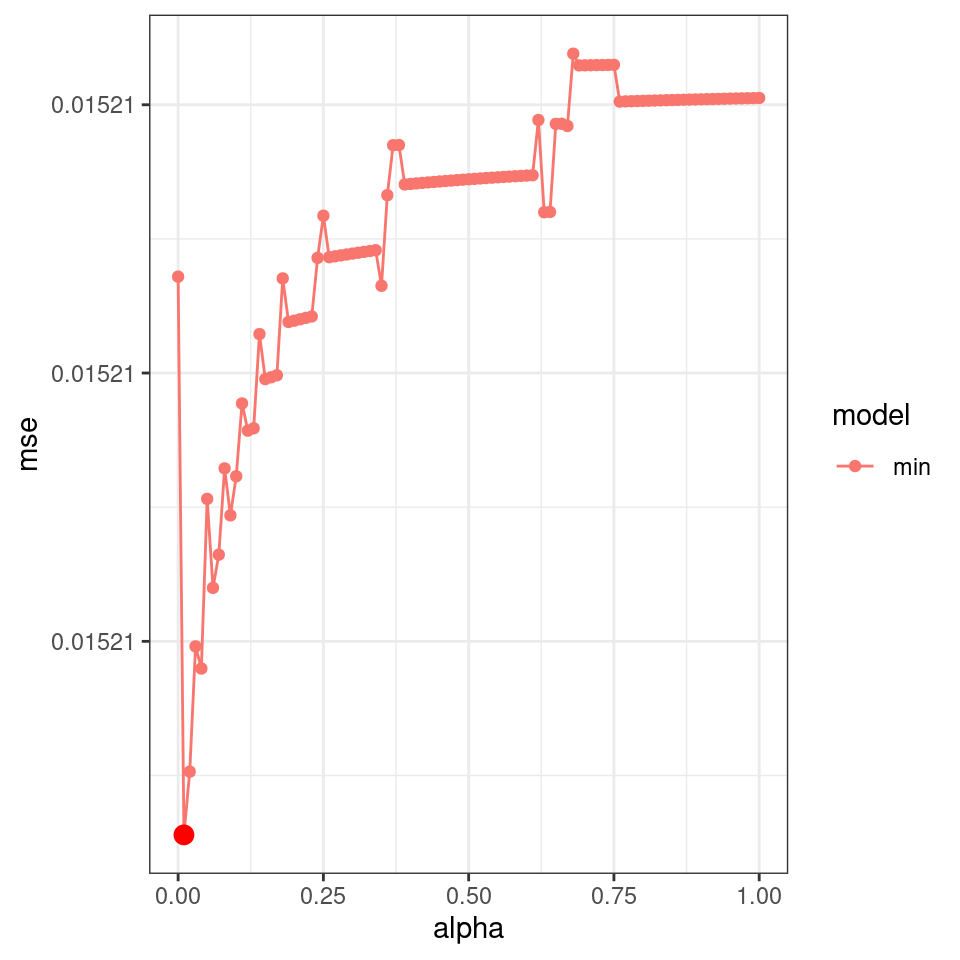

```r
library(readr)
library(knitr)

set.seed(200)

train_url = "https://mdporter.github.io/SYS6018/data/linkage_train.csv"
test_url = "https://mdporter.github.io/SYS6018/data/linkage_test.csv"

train_reader = readr::read_csv(train_url)
test_reader  = readr::read_csv(test_url)

data_train.X = model.matrix(~ 0 + spatial + temporal + tod + dow + LOC + POA + MOA + TIMERANGE, data = train_reader)
data_train.y = model.matrix(~ 0 + y, data = train_reader)

# load the test dataset
data_test.X  = model.matrix(~ 0 + spatial + temporal + tod + dow + LOC + POA + MOA + TIMERANGE, data = test_reader)


#Set the fitting and fit the
n.fold = 10

alpha.range = seq(0,1,by=0.01)

cvRes.1a = tibble(model = str_c(),mse = numeric(), alpha = numeric(), lambda = numeric())
fold = sample(rep(1:n.fold, length=nrow(data_train.X)))
for (alpha in alpha.range) {

  fit.enet = cv.glmnet(data_train.X,data_train.y,alpha = alpha, foldid = fold)

  mse.min.enet = fit.enet$cvm[fit.enet$lambda == fit.enet$lambda.min]
  mse.1se.enet = fit.enet$cvm[fit.enet$lambda == fit.enet$lambda.1se]

  lambda.min = fit.enet$lambda.min
  lambda.1se = fit.enet$lambda.1se

  cvRes.1a = add_row(cvRes.1a, model = "min", alpha = alpha, mse = mse.min.enet,lambda = lambda.min)
  #cvRes.1a = add_row(cvRes.1a, model = "1se", alpha = alpha, mse = mse.1se.enet,lambda = lambda.1se)
}

ggplot(cvRes.1a,aes(x = alpha,y=mse,color = model)) + geom_point() + geom_line() +
  geom_point(data =. %>% filter(mse == min(mse)),color="red",size=3)
```

The Best $\alpha$ and $\lambda$ we choose from the previous fit would be :

```r
minRes <- cvRes.1a %>% filter(mse == min(mse))
minRes %>% kable()
```

| model | mse | alpha | lambda |
| --- | --- | --- | --- |
| min | 0.0152 | 0.01 | 9e-04 |

At best $\alpha$ and $\lambda$ location, the coeffcient would be :

```r
alpha.choose.1a = minRes$alpha
fit.enet.1a = cv.glmnet(data_train.X,data_train.y,alpha = alpha.choose.1a, foldid = fold)
#plot(fit.enet.1a)

# prepare the Q.c
yhat.enet  = predict(fit.enet.1a,data_train.X, s="lambda.min",type="response")
gamma.enet = predict(fit.enet.1a,data_train.X, s="lambda.min",type="link")
coef(fit.enet.1a,s="lambda.min")
```

```
#> 9 x 1 sparse Matrix of class "dgCMatrix"
#>                      1
#> (Intercept)  9.341e-02
#> spatial     -2.343e-03
#> temporal    -1.564e-04
#> tod         -2.232e-03
#> dow         -5.847e-03
#> LOC          4.305e-02
#> POA          9.380e-03
#> MOA          7.326e-03
#> TIMERANGE    2.523e-05
```

## b. Fit a penalized *logistic regression* model. Use a lasso, ridge, or elasticnet penalty (your choice).

- Report the value of $\alpha$ used (if elasticnet)
- Report the value of $\lambda$ used
- Report the estimated coefficients

ADD SOLUTION HERE

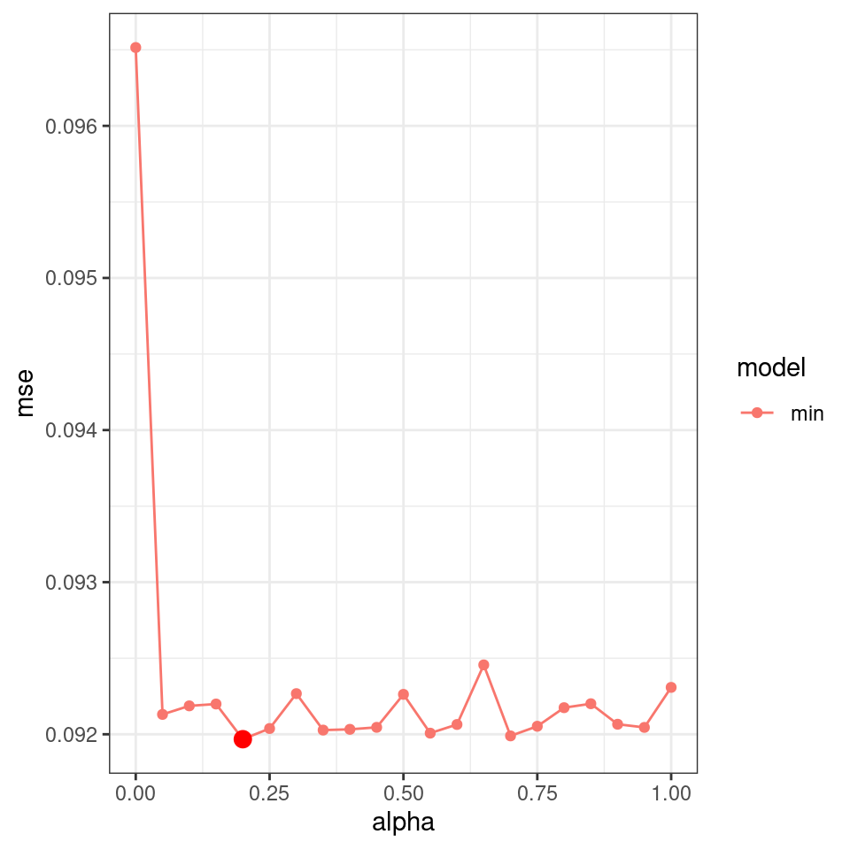

```r
set.seed(2020)

cvRes.1b = tibble(model = str_c(), mse =numeric(), alpha = numeric(), lambda = numeric())
alpha.range = seq(0,1, by =0.05)

for (alpha  in alpha.range) {
  fit.logistic.1b = cv.glmnet(y~spatial + temporal + tod + dow + LOC +POA +MOA + TIMERANGE, data=train_reader,
                     alpha=alpha,family="binomial")
  mse.min.enet = fit.logistic.1b$cvm[fit.logistic.1b$lambda == fit.logistic.1b$lambda.min]
  mse.1se.enet = fit.logistic.1b$cvm[fit.logistic.1b$lambda == fit.logistic.1b$lambda.1se]
  lambda.min = fit.logistic.1b$lambda.min
  lambda.1se = fit.logistic.1b$lambda.1se
  cvRes.1b = add_row(cvRes.1b,model = "min",alpha = alpha,  mse = mse.min.enet, lambda = lambda.min)
}

ggplot(cvRes.1b,aes(x = alpha,y=mse,color = model)) + geom_point() + geom_line() +
  geom_point(data =. %>% filter(mse == min(mse)),color="red",size=3)
```

- The Best $\alpha$,$\lambda$ used in the fitting:

```r
minRes <- cvRes.1b %>% filter(mse == min(mse))
minRes %>% kable()
```

| model | mse | alpha | lambda |
| --- | --- | --- | --- |
| min | 0.092 | 0.2 | 1e-04 |

- estimated coefficients

```r
alpha.choose.1b = minRes$alpha
fit.logistic.1b = cv.glmnet(y~spatial + temporal + tod + dow + LOC +POA +MOA + TIMERANGE, data=train_reader,
                     alpha=alpha.choose.1b,family="binomial")

#prepare the Q.c
yhat.logistic  = predict(fit.logistic.1b,data_train.X, s="lambda.min",type="response")
gamma.logistic = predict(fit.logistic.1b,data_train.X, s="lambda.min",type="link")
```

```r
#plot(fit.logistic.1b)
coef(fit.logistic.1b, s="lambda.min")
```

```
#> 9 x 1 sparse Matrix of class "dgCMatrix"
#>                      1
#> (Intercept) -0.0360141
#> spatial     -0.2839147
#> temporal    -0.0124292
#> tod         -0.1137371
#> dow         -0.2418643
#> LOC          1.3909324
#> POA          0.4447171
#> MOA          0.2156021
#> TIMERANGE    0.0006177
```

## c. Produce one plot that has the ROC curves, using the *training data*, for both models (from part a and b). Use color and/or linetype to distinguish between models and include a legend.

ADD SOLUTION HERE

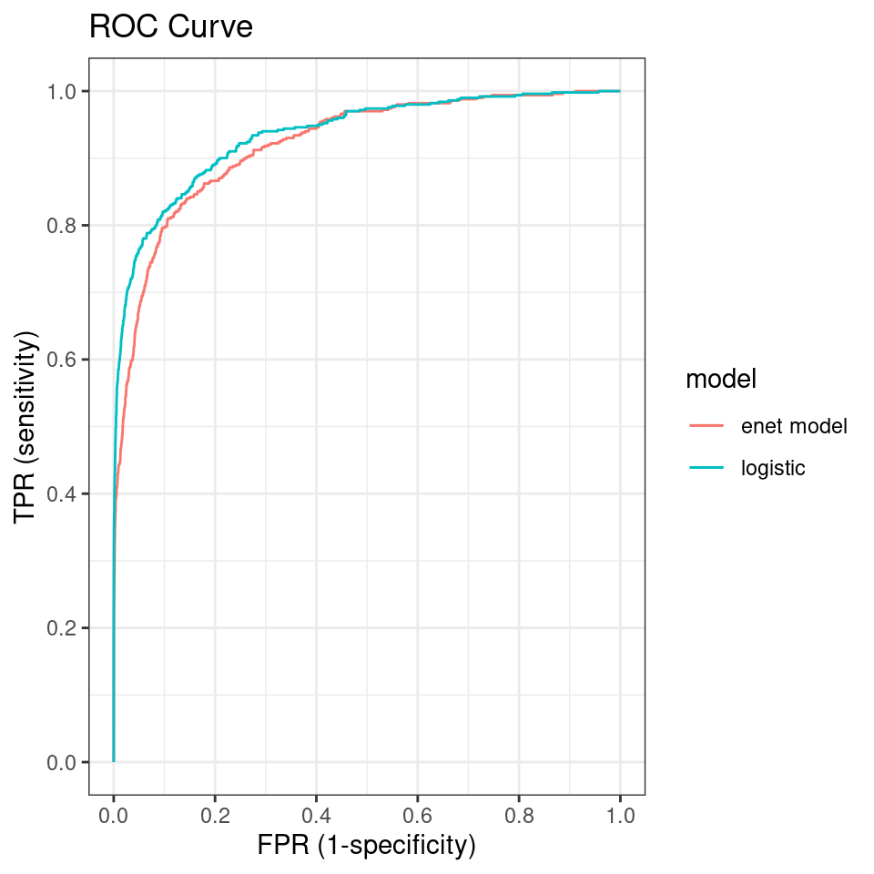

```r
perf.enet = tibble(truth = data_train.y, gamma.enet,yhat.enet) %>%
  group_by(gamma.enet,yhat.enet) %>%
  summarize(n=n(), n.1=sum(truth), n.0=n-sum(truth)) %>% ungroup() %>%
  #- calculate metrics
  arrange(gamma.enet) %>%
  mutate(FN = cumsum(n.1),    # false negatives
         TN = cumsum(n.0),    # true negatives
         TP = sum(n.1) - FN,  # true positives
         FP = sum(n.0) - TN,  # false positives
         N = cumsum(n),       # number of cases predicted to be 1
         TPR = TP/sum(n.1), FPR = FP/sum(n.0)) %>%
  #- only keep relevant metrics
  select(-n, -n.1, -n.0, gamma.enet, yhat.enet)

# build the logistic regression result
perf.logistic = tibble(truth = data_train.y,gamma.logistic,yhat.logistic) %>%
  group_by(gamma.logistic,yhat.logistic) %>%
  summarize(n=n(), n.1=sum(truth), n.0=n-sum(truth)) %>% ungroup() %>%
  #- calculate metrics
  arrange(gamma.logistic) %>%
  mutate(FN = cumsum(n.1),    # false negatives
         TN = cumsum(n.0),    # true negatives
         TP = sum(n.1) - FN,  # true positives
         FP = sum(n.0) - TN,  # false positives
         N = cumsum(n),       # number of cases predicted to be 1
         TPR = TP/sum(n.1), FPR = FP/sum(n.0)) %>%
  #- only keep relevant metrics
  select(-n, -n.1, -n.0, gamma.logistic, yhat.logistic)

ggplot()+
  geom_path(data=perf.enet,aes(FPR, TPR,color="enet model")) +
  geom_path(data=perf.logistic,aes(FPR, TPR,color="logistic")) +
  labs(x='FPR (1-specificity)', y='TPR (sensitivity)',color='model') +
  geom_segment(x=0, xend=1, y=0, yend=1, lty=3, color='grey50') +
  scale_x_continuous(breaks = seq(0, 1, by=.20)) +
  scale_y_continuous(breaks = seq(0, 1, by=.20)) +
  ggtitle("ROC Curve")
```

## d. Recreate the ROC curve from the penalized logistic regression model using repeated hold-out data. The following steps will guide you:

- Fix $\alpha=.75$
- Run the following steps 25 times:
1. Hold out 500 observations
2. Use the remaining observations to estimate $\lambda$
3. Predict the probability of the 500 hold-out observations
4. Store the predictions and hold-out labels
- Combine the results and produce the hold-out based ROC curve
- Note: by estimating $\lambda$ each iteration, we are incorporating the uncertainty present in estimating that tuning parameter.

ADD SOLUTION HERE

```r
set.seed(2021)
steps = 25
alpha = 0.75
holdout = 500

cvRes.d = tibble()
for( step in 1:steps){
  # prepare the training and test dataset
  test = sample(nrow(train_reader),size = holdout)  ## sample 500 to hold
  train = -test

  dataSet_train  = train_reader[train,]
  dataSet_train.X = dataSet_train %>% select(-y) %>% as.matrix()
  dataSet_train.y = dataSet_train %>% select(y) %>% as.matrix()

  dataSet_test   = train_reader[test,]
  dataSet_test.X = dataSet_test %>% select(-y) %>% as.matrix()
  dataSet_test.y = dataSet_test %>% select(y) %>% as.matrix()

  fit.logistic.step = cv.glmnet(x=dataSet_train.X, y= dataSet_train.y,alpha = alpha, family="binomial")

  # buffer the result
  gamma  = predict(fit.logistic.step, dataSet_test.X, s="lambda.min",type="link")
  yhat   = predict(fit.logistic.step, dataSet_test.X, s="lambda.min",type="response")
  res = tibble(step = step, trueVal = dataSet_test.y, gamma = gamma, yhat = yhat)
  cvRes.d = bind_rows(cvRes.d, res)
}
```

```r
## post-process, get the result and generate the result
perf = tibble(truth = cvRes.d$trueVal, gamma = cvRes.d$gamma, yhat = cvRes.d$yhat) %>%
    group_by(gamma,yhat) %>%
    summarize(n=n(), n.1=sum(truth), n.0=n-sum(truth)) %>% ungroup() %>%
    #- calculate metrics
    arrange(gamma) %>%
    mutate(FN = cumsum(n.1),    # false negatives
           TN = cumsum(n.0),    # true negatives
           TP = sum(n.1) - FN,  # true positives
           FP = sum(n.0) - TN,  # false positives
           N = cumsum(n),       # number of cases predicted to be 1
           TPR = TP/sum(n.1), FPR = FP/sum(n.0)) %>%
    #- only keep relevant metrics
    select(-n, -n.1, -n.0, gamma, yhat)
```

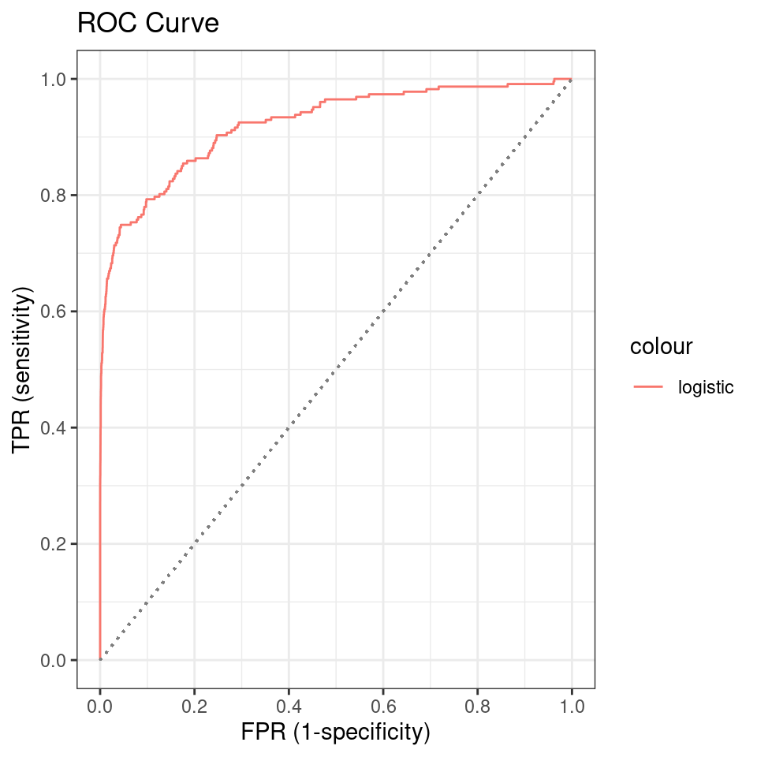

```r
ggplot(perf,aes(FPR,TPR,color="logistic")) + geom_path()+
  labs(x='FPR (1-specificity)', y='TPR (sensitivity)') +
  geom_segment(x=0, xend=1, y=0, yend=1, lty=3, color='grey50') +
  scale_x_continuous(breaks = seq(0, 1, by=.20)) +
  scale_y_continuous(breaks = seq(0, 1, by=.20)) +
  ggtitle("ROC Curve")
```

## e. Contest Part 1: Predict the estimated *probability* of linkage for the test data (using any model).

- Submit a .csv file (ensure comma separated format) named `lastname_firstname_1.csv` that includes the column named **p** that is your estimated posterior probability. We will use automated evaluation, so the format must be exact.
- You are free to use any tuning parameters
- You are free to use any data transformation or feature engineering
- You will receive credit for a proper submission; the top five scores will receive 2 bonus points.
- Your probabilities will be evaluated with respect to the mean negative Bernoulli log-likelihood (known as the average *log-loss* metric)
  $$L = - \frac{1}{M} \sum_{i=1}^m [y_i \log \, \hat{p}_i + (1 - y_i) \log \, (1 - \hat{p}_i)]$$
  where $M$ is the number of test observations, $\hat{p}_i$ is the prediction for the $i$th test observation, and $y_i \in \{0,1\}$ are the true test set labels.

ADD SOLUTION HERE

From the result of the previous question, it seems like the logistic model is better. Here in the prediction, we will use the logistic model.

```r
yhat = predict(fit.logistic.1b,data_test.X,s="lambda.min",type = 'response')
colnames(yhat)[1] <- "p"
write.csv(yhat,"jian_siyu_1.csv")
```

## f. Contest Part 2: Predict the linkages for the test data (using any model).

- Submit a .csv file (ensure comma separated format) named `lastname_firstname_2.csv` that includes the column named **linkage** that takes the value of 1 for linkages and 0 for unlinked pairs. We will use automated evaluation, so the format must be exact.
- You are free to use any tuning parameters.
- You are free to use any data transformation or feature engineering.
- Your labels will be evaluated based on total cost, where cost is equal to `1*FP + 8*FN`. This implies that False Negatives (FN) are 8 times as costly as False Negatives (FP)
- You will receive credit for a proper submission; the top five scores will receive 2 bonus points. Note: you only will get bonus credit for one of the two contests.

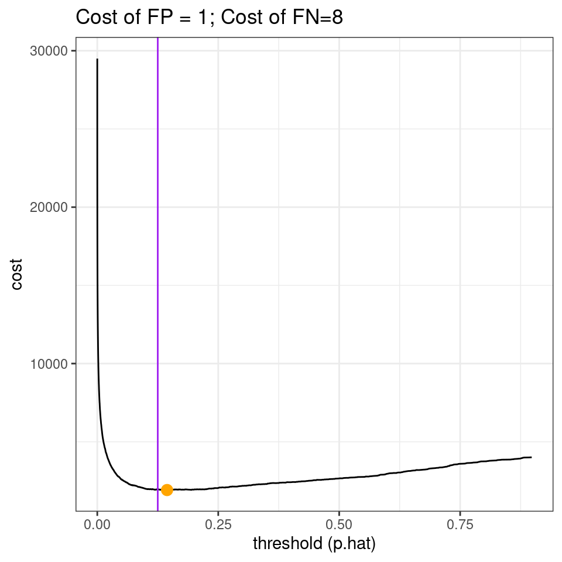

```r
# idea, on the trainning dataset, get the cost curves, and find the threashold on the minimum threshold
#-- Make Cost curves
perfcost = perf.logistic %>% mutate(cost = 1*FP + 8*FN)
perfcost %>%   # use 1:10 costs
  ggplot(aes(yhat.logistic, cost)) + geom_line() +
  geom_point(data=. %>% filter(cost==min(cost)), size=3, color='orange') + # # optimal from test data
  geom_vline(xintercept = 1/8, color='purple') +  # theoretical optimal
  ggtitle('Cost of FP = 1; Cost of FN=8') +
  labs(x="threshold (p.hat)")
```

```r
yhatThres = perfcost %>% filter(cost==min(cost)) %>% select(yhat.logistic)

yhatThresVal = yhatThres$yhat.logistic[,1]
yhat  = predict(fit.logistic.1b,data_test.X,s="lambda.min", type = 'response')
predictRes = ifelse(yhat >= yhatThresVal, 1, 0)
# rename the column
colnames(predictRes)[1] <- "linkage"
write.csv(predictRes,"jian_siyu_2.csv")
```